# Un’analisi comparativa di quattro piattaforme Etherscan

Olivia Modesto

2025-04-11

## Introduzione

L’obiettivo di questo progetto è confrontare alcuni strumenti che consentono di interagire con le blockchain. Le metodologie studiate sono: Blockchain Explorers, Blockchain APIs, Piattaforme tipo SQL e Librerie Web3. Per ogni tipologia è stata scelta una piattaforma di esempio. Gli strumenti scelti sono rispettivamente Etherscan, Etherscan API, Dune Analytics, Web3.py.  
All’inizio vengono presentate le diverse piattaforme. Successivamente sono analizzate e confrontate fra loro in base all’usabilità, alle risorse disponibili e ai costi.  
Per completare il confronto, questi strumenti sono stati applicati ad un caso di studio: il crollo della stablecoin Terra e del token relativo Luna. Vengono identificati alcuni eventi che hanno portato al loro collasso. I segni lasciati da questi eventi si possono in parte trovare sulla blockchain. Si utilizzano le diverse piattaforme per recuperare questi segni e ricostruire la sequenza di eventi.

## Gli strumenti

### Etherscan : un blockchain explorer

I Blockchain Explorers forniscono interfacce pubbliche che permettono di ottenere informazioni sui dati della blockchain. L’interfaccia studiata è Etherscan. Etherscan offre numerose funzionalità per l’analisi dei dati sulla catena Ethereum e per l’interazione con gli smart contracts. (2025a)

[figure not shown]

La homepage mostra in primo piano le informazioni più importanti riguardo alla cryptovaluta ETH: il prezzo, il numero totale di transazioni, il prezzo medio del gas, il market cap, l’ultimo blocco confermato in modo definitivo, l’ultimo blocco non confermato in modo definitivo.  
Sotto a questa parte ci sono le ultime transazioni completate e gli ultimi blocchi minati.  
In alto a sinistra c’è una barra di ricerca. Con questa si possono cercare token, wallet, singoli blocchi e altro utilizzando gli indirizzi, le hash oppure i nomi pubblici. È possibile specificare un criterio di ricerca:

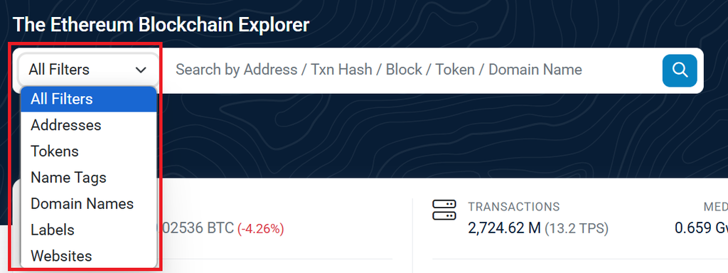

Sono state svolte tre prove con la barra di ricerca. Se la ricerca porta a un solo risultato, Etherscan porta direttamente alla sua pagina. Se la chiave di ricerca porta a molteplici risultati, Etherscan propone una pagina in cui sono elencati i risultati ottenuti. In questa pagina viene proposto un secondo filtro che permette di scegliere il tipo di oggetto cercato. Si può scegliere tra token, indirizzi e nomi di dominio.  
Le parole chiave cercate sono *Luna*, *LUNC*, e l’indirizzo esadecimale del contratto del token LUNC. Per ognuna di queste parole sono stati provati tutti i filtri proposti nella barra di ricerca. Quello che emerge è che utilizzare i filtri non cambia i risultati ottenuti. Con le parole *Luna* e *LUNC* sono proposti sempre gli stessi risultati. Con l’indirizzo esadecimale Etherscan porta direttamente alla pagina del contratto.  
Invece, il filtro proposto nella pagina dei risultati sembra effettivamente funzionare, riducendo il numero di risultati in base all’opzione selezionata.

[figure not shown]

In alto a destra c’è il menù principale. Questo ha sei voci: *Blockchain*, *Token*, *NFTs*, *Resources*, *Developers*, *More*. Queste sei offrono dei link agli strumenti e alle risorse disponibili.  
*Blockchain* offre link a risorse riguardanti transazioni e blocchi.

[figure not shown]

Il link *Transactions* porta ad una pagina in cui sono elencate tutte le transazioni avvenute. Il link *Pending Transactions* collega ad una pagina in cui sono visualizzate tutte le transazioni in attesa. Inoltre questa pagina propone un link alla pending transaction pool.  
In modo simile il link *Contract Internal Transactions* propone l’elenco di tutte le transazioni interne. Su Etherscan per transazioni interne si intende quei trasferimenti avvenuti eseguendo un contratto (2025b).  
Il link *Beacon Deposits* propone gli eth2 Beacon Chain deposits. Attualmente la Beacon Chain è una rete peer-to-peer che si occupa dello strato di consenso. La Beacon Chain permette di utilizzare la proof-of-stake su Etherscan (2025c). *Beacon Deposits* propone i depositi effettuati per lo staking.  
Il link *Beacon Withdrawals* propone i Processed Beacon Chain Withdrawals. Questa pagina traccia gli spostamenti di ETH dei validatori.  
Il link *View Blobs* propone le transazioni di tipo *blob*. Le transazioni *blob* sono state introdotte per permettere transazioni con grandi quantità di dati che persistono nel beacon node per un breve periodo di tempo (2025d).  
Il link *AA Transactions* propone due pagine: *AA Transactions* e *Bundle Transaction*.  
Le Account Abstraction Transactions sono transazioni svolte da smart contract (2025e). La pagina *AA Transactions* presenta un elenco di queste operazioni.  
Le Bundle Transactions sono pacchetti di una o più transazioni che passano informazioni alle transazioni successive (2025f). La pagina *Bundle Transaction* propone un elenco di queste operazioni. Il link *View Blocks* porta ad una pagina in cui sono elencati tutti i blocchi della catena Ethereum.  
Il link *Forked Blocks* porta ad una pagina in cui sono elencati tutti i forked blocks. Su Ethereum, nel momento in cui è necessario cambiare le regole possono essere creati dei split temporanei nella network. I nuovi blocchi possono essere generati utilizzando le nuove oppure le vecchie regole. Questi split possono essere temporanei o permanenti (2025g). Questo elenco esclude i blocchi forked a causa di “Chain Reorganization” (2025h).  
Il link *Uncles* porta ad una pagina in cui sono elencati tutti i blocchi detti *Uncles*. Questi sono blocchi validi che non sono parte della principale catena di Ethereum perché sono stati sottoposti troppo tardi (2025h).  
Il link *Top Accounts* propone un classifica degli account ordinati in base al proprio bilancio in ETH.  
Il link *Verified Contracts* propone l’elenco dei smart contracts verificati. Su Ethereum esistono due forme di verifica: la source code verification e la formal verification. La source code verification verifica se il codice sorgente di uno smart contract produce lo stesso bytecode prensente all’indirizzo del smart contract. La formal verification verifica la correttezza dello smart contract, ovvero se il contratto si comporta come previsto. In questo caso per verifica si intende la source code verification (2025i).  
*Token* offre link alle risorse riguardanti i token più popolari.

[figure not shown]

Il link *Top Tokens* propone un elenco di tutti i token ERC-20 con reputazione OK oppure Neutra. ERC-20 (Ethereum Request for Comment 20) è uno standard tecnico per gli asset su catena Ethereum (2025j). Le reputazioni sono delle valutazioni fatte da Etherscan. Queste aiutano gli utenti a prendere decisioni informate.

Un token ha una reputazione Neutra se:

1. Ci sono informazioni sufficienti riguardanti il progetto e il suo team. Queste informazioni forniscono trasparenza.
2. Il codice sorgente del contratto è verificato.
3. Ci sono sufficienti informazioni fornite su website, logo, official contact email.
4. Sono forniti i profili professionali dei membri dei team e consulenti. Questi profili possono anche essere disponibili sul sito.
5. Il progetto mantiene un sito web funzionante con profili social attivi e canali di comunicazione.
6. Non ci sono ‘red’ flags significative nel momento in cui il punteggio è stato assegnato.
7. Il token è quotato sulle principali piattaforme di aggregazioni di prezzi (Coingecko e Coinmarketcap).

Un token ha reputazione OK se :

1. Rispetta le condizioni per essere considerato Neutro.
2. Fornisce informazioni accurate e sufficienti.
3. Ci sono chiari obiettivi di progetto e informazioni accurate.
4. I profili dei principali fondatori, sostenitori, consulenti del progetto sono visibili.
5. Il token è quotato sulle principali piattaforme di exchange che usano controlli AML (Anti Money Laundering) o KYC (Know Your Customer).
6. Ha raggiunto milestones significative. (2025k)

Il link *Token Transfers* propone un elenco di trasferimenti di token ERC-20.

*NFTs* offre link a risorse riguardanti i NFT.

[figure not shown]

Il link *Top NFTs* propone un elenco di collezioni NFT disponibili sulla piattaforma Ethereum ordinati in base al volume. Per volume si intende la quantità totale di ETH scambiata per quella collezione durante il ciclo di vita di un progetto (2025l). Il link *Top Mints* propone un elenco di top NFT mints. Il link *Latest Trades* propone un elenco dei trades più recenti di NFT. È possibile specificare il marketplace di interesse.

[figure not shown]

[figure not shown]

Il link *Charts And Stats* propone una serie di interfacce interattive nelle quali sono proposti grafi e dashboard. Ci sono sei gruppi di interfacce: *Market Data*, *Blockchain Data*, *Dashboards*, *Network Data*, *Top Statistics*, *Contracts*.

[figure not shown]

[figure not shown]

Il link *Newsletter* propone la newsletter di Etherscan. In questa sono discussi svariati argomenti. Il link *Knowledge Base* propone link alla documentazione disponibile riguardo Etherscan.  
*Developers* offre link a risorse che possono essere utili per gli sviluppatori.

[figure not shown]

*API Plans* riporta i possibili piani tariffari e link alla documentazione dell’API. *API Documentation* propone link alla documentazione dell’API. *Code Reader* propone un AI che interpreta il codice di uno smart contract e risponde a domande su di esso. Le AI disponibili sono GPT-3.5, GPT-4 e Groq. Al momento (11/03/2025) questo strumento è ancora relativamente nuovo e prima di accedere viene proposta una finestra con un elenco di avvertenze. *Code Reader* richiede un account e una chiave API attiva.

[figure not shown]

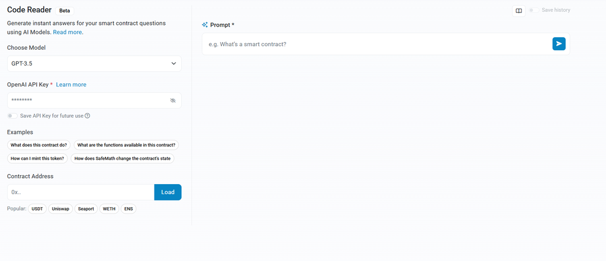

*Verify Contracts* permette di verificare e pubblicare codice sorgente di un smart contract. I linguaggi supportati sono Solidity e Vyper. È possibile selezionare la versione da utilizzare.

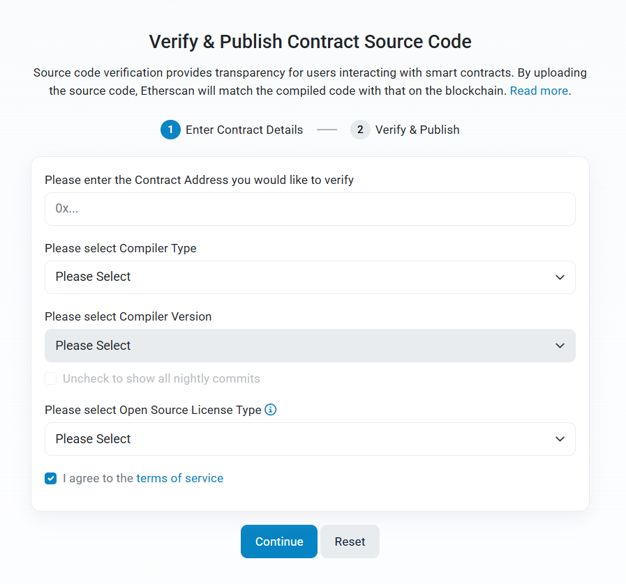

*Similar Contract Search* permette di cercare contratti con codice simile a quello di un contratto specificato.

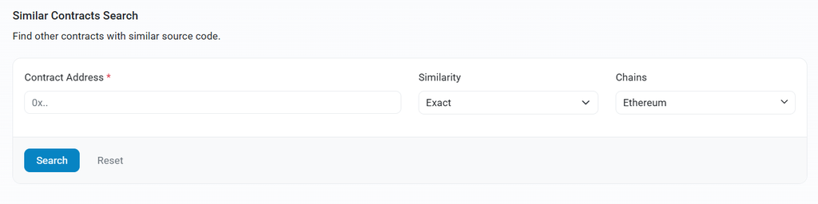

*Smart Contract Search* permette di cercare il codice sorgente di smart contract in base al contratto, all’indirizzo del deployer, alla data di creazione, al numero del blocco e ad altro.

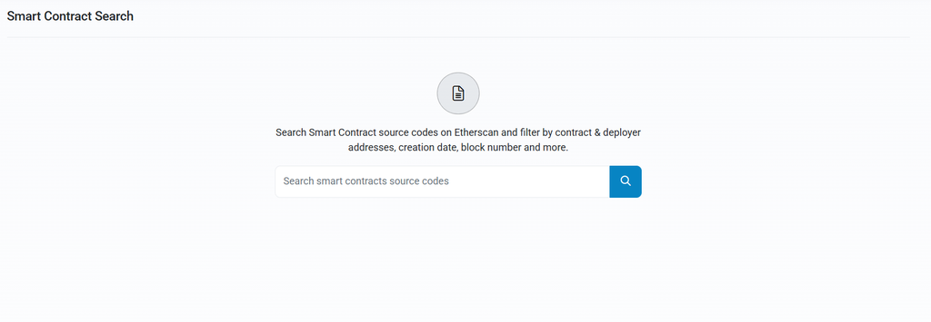

*Contract Diff Checker* permette di confrontare due contratti.

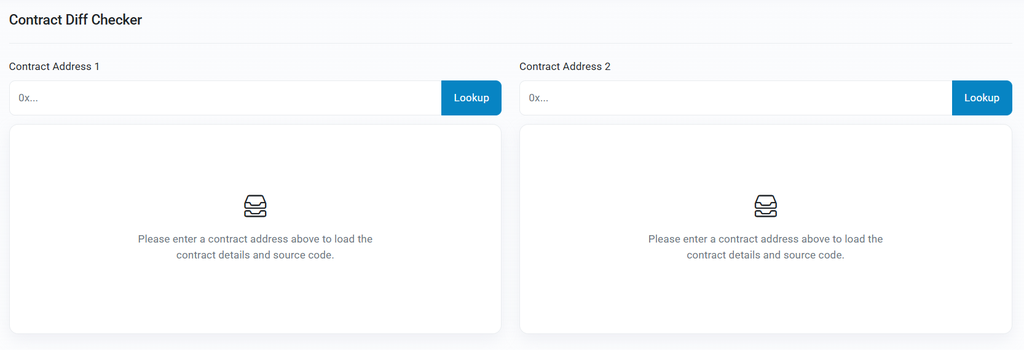

La pagina *Vyper Online Compiler* propone un compilatore online di linguaggio Vyper. È possibile specificare la versione da utilizzare. La pagina *Bytecode to Opcode* propone una pagina dove è possibile tradurre il bytecode di basso livello a opcode. La pagina *Broadcast Transaction* propone una pagina dove è possibile trasmettere una Signed Raw Transaction su Ethereum. La transazione deve essere specificata in formato esadecimale. Il link *More* offre link a servizi miscellanei. La voce *More* ha tre voci principali : *Tools*, *Explore*, *Services*.

[figure not shown]

La voce *Tools* propone : *Input Data Decoder*, *Unit Converter*, *CSV Export*, *Account Balance Checker*.  
La pagina *Input Data Decoder* permette di interpretare e analizzare i dati mandati ai smart contracts. Richiede di specificare la hash della transazione. La pagina *Unit Converter* permette di convertire valori numerici tra Wei e Gwei. Wei è la più piccola unità di misura di Ether (2025n). Il Gwei è un multiplo del Wei. La pagina *CSV Export* permette di scaricare dati in formato csv. È possibile specificare che dati scaricare e l’intervallo di tempo con precisione giornaliera. È proposta un’ampia gamma di dati scaricabili: i token, i trasferimenti, il codice sorgente degli smart contract. **Questa funzionalità risulta molto utile se si vuole rielaborare ulteriormente i dati.**  
La pagina *Account Balance Checker* permette di consultare lo storico del bilancio Ether oppure Token di un account.  
La voce *Explore* propone : *Gas Tracker*, *DEX Tracker*, *Node Tracker*, *Label Cloud*, *Domain Name Lookup*.  
La pagina *Gas Tracker* propone informazioni riguardanti il gas. Essa propone una stima del costo minimo, medio e massimo del gas espresso in gwei. Sono proposti dei grafi riassuntivi sullo storico del costo del gas. Infine propone quattro classifiche : *Gas Guzzlers*, una classifica dei contratti in base alla quantità di gas consumato, *Gas Spenders*, una classifica degli account in base alla quantità di gas consumato, *Historical Gas Oracle Prices*, lo storico dei prezzi del gas in gwei, *Cost of Transaction Actions*, un elenco del costo delle transazioni espresso in dollari. La pagina *DEX Tracker* propone le pagine Transactions e Trading Pairs. La pagina *Node Tracker* mostra le statistiche dei nodi sulla network. Queste statistiche comprendono la classifica dei 10 paesi con più elevato numero di nodi, il numero totale di nodi giornalieri, il tipo di nodo in base ai clienti e al sistema operativo.  
La pagina *Label Cloud* propone la Label Word Cloud.

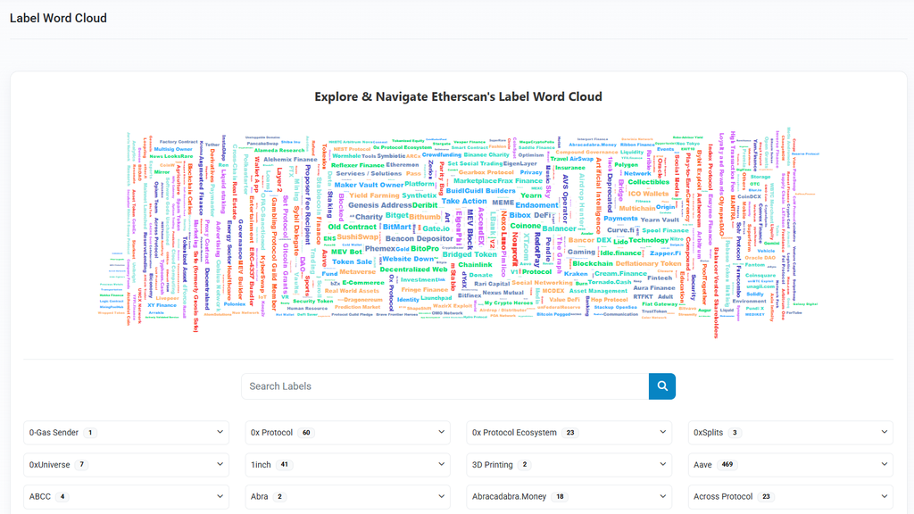

La pagina *Domain Name Lookup* permette di cercare un indirizzo utilizzando il domain name.  
La voce *Services* propone : *Token Approvals*, *Verified Signature*, *Input Data Messages*, *Advanced Filter*, *Blockscan Chat*.  
La pagina *Token Approvals* permette di valutare e revocare i propri token approvals per qualsiasi dApp. Un token approval permette ad uno smart contract di spendere i token a nome di un utente (2025o). La pagina *Verified Signature* permette di visualizzare, firmare e verificare le message signatures utilizzando indirizzi Ethereum. La pagina *Input Data Messages (IDM)* permette di visualizzare i messaggi mandati tra account Ethereum.  
La pagina *Advanced Filter* permette di creare i filtri avanzati accennati in precedenza. È possibile specificare i seguenti filtri: *Type*, *Method*, *Age*, *From*, *OR/AND*, *To*, *Amount*, *Asset*.

[figure not shown]

Come risultati del filtro viene proposto un barplot e un elenco delle transazioni che rispettano i filtri. A sinistra, sopra il barplot, esiste la voce *Filter By* che elenca i filtri in uso. A destra esiste la voce *Display Chart*, che permette di chiudere e aprire il barplot.  
La voce *Additional Filter* permette di specificare un *Event Log* da aggiungere ai filtri, specificando *Address* e *Topic 0*. La voce *Presets* permette di specificare gli *Swap* e *Bridge* su cui avvengono le transazioni. La voce *Columns* permette di selezionare quali colonne visualizzare.  
Il filtro *Type* permette di specificare che tipo di transazione visualizzare. Il filtro *Method* permette di specificare il tipo di operazione. Il filtro *Age* permette di specificare l’intervallo di tempo di interesse. Il filtro *From* permette di filtrare in base all’indirizzo del mittente. Il filtro *OR/AND* specifica la relazione tra la coppia dei valori *From* e *To*. Il filtro *To* permette di filtrare in base all’indirizzo del destinatario. Il filtro *Amount* permette di specificare l’intervallo della quantità trasferita. Il filtro *Asset* permette di filtrare in base all’asset.  
È stato creato un filtro per i token USTC e LUNC durante i primi sei mesi del 2022.

[figure not shown]

*Blockscan Chat* porta alla piattaforma di comunicazione Blockscan.

La pagina *Ether Mining Calculator* permette di ottenere una stima dei guadagni sia in ETH che in dollari. Questa pagina non viene proposta direttamente nel menu principale (aggiornato al 22/03/2025), ma è raggiungibile dal link https://etherscan.io/ether-mining-calculator.

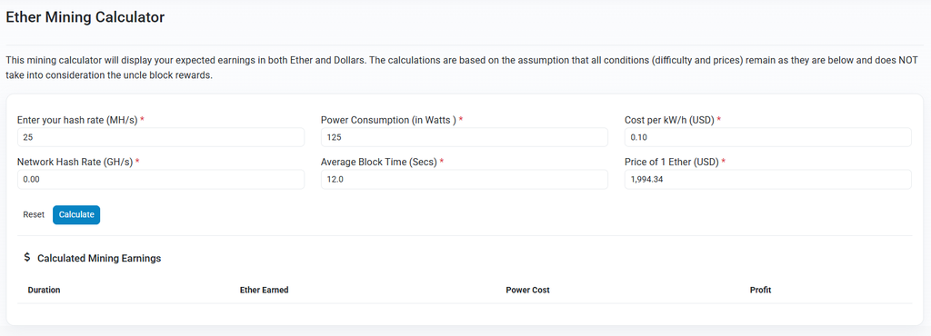

**Come si vede Etherscan offre moltissime informazioni e funzionalità.**

### Etherscan API : una blockchain API

Le Blockchain API forniscono interfacce che permettono di interrogare la Blockchain in modo programmatico. L’API studiata è Etherscan API. Etherscan API estende le funzionalità di Etherscan. Richiede la creazione di un account. Mediante il proprio account è possibile generare delle chiavi che consentono di effettuare query all’API tramite richieste HTTPS.  
Accedendo all’area personale, viene proposto un overview delle risorse utilizzate dall’utente e di quelle disponibili.

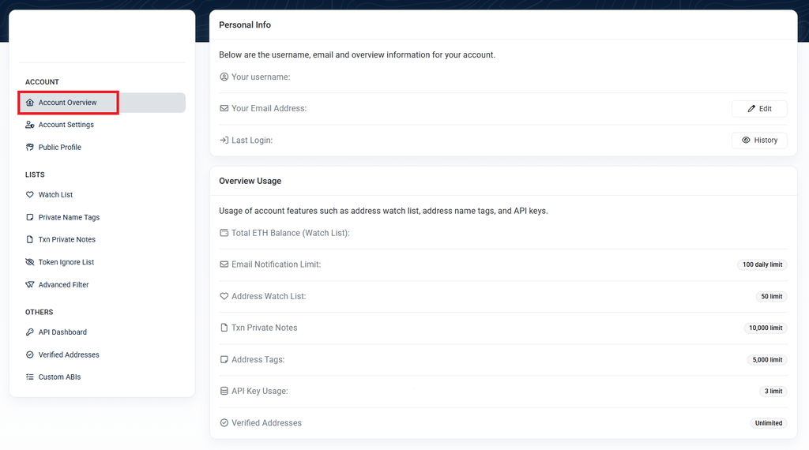

Sotto la voce *API Dashboard* sono disponibili informazioni riguardo le chiavi dell’utente e statistiche riguardo l’utilizzo.

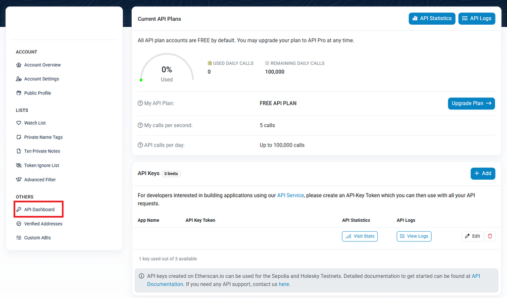

La voce *Visit Stats* mette a disposizione statistiche riguardo le chiamate e *View Logs* fornisce i log delle chiamate.

La voce *Verified Addresses* permette di dimostrare che l’utente possiede un determinato indirizzo Ethereum utilizzato per creare smart contracts. Questa verifica permette all’utente di aggiornare le informazioni del token e l’address name tag (etichetta personalizzata per rendere un indirizzo facilmente riconoscibile) senza dover firmare ogni volta un nuovo messaggio.

[figure not shown]

La voce *Custom ABI* permette di aggiungere un’ABI per un contratto non verificato. L’ABI (Application Binary Interface) di uno smart contract è un’interfaccia che permette al contratto di comunicare con applicativi esterni o altri smart contract (2025p).

[figure not shown]

La chiave API si utilizza direttamente negli url.

Gli endpoints disponibili gratuitamente sono: *Accounts*, *Contracts*, *Transactions*, *Blocks*, *Logs*, *Geth/Parity Proxy*, *Tokens*, *Gas Tracker*, *Stats*. Li discutiamo uno ad uno.

L’endpoint *Accounts* permette di ottenere informazioni riguardo specifici account. Più precisamente:

- informazioni su specifici wallet conoscendo i loro hash address.
- le transazioni interne in base all’indirizzo, hash o intervallo di blocchi.
- il tipo di token trasferiti (ERC20, ERC712, ERC1155) conoscendo l’indirizzo di trasferimento.
- l’elenco di blocchi validati da un indirizzo specifico.
- il beacon chain withdrawal in base all’indirizzo oppure all’intervallo di blocchi.
- lo storico del bilancio in ETH per un specifico indirizzo.

L’endpoint *Contracts* permette di ottenere le seguenti informazioni sui smart contract:

- l’ABI per un contratto verificato.
- il codice sorgente di un contratto verificato.
- la hash e il creatore del contratto.

Inoltre consente di eseguire le seguenti operazioni:

- verificare un contratto scritto in Solidity oppure Vyper.
- controllare lo stato di verifica di un contratto.
- verificare un Proxy Contract utilizzando cURL.
- controllare lo stato di una richiesta di verifica di un Proxy Contract utilizzando cURL.

L’endpoint *Transactions* permette di:

- controllare lo stato di esecuzione di un contratto.
- controllare lo stato di una transazione.

L’endpoint *Blocks* permette di ottenere informazioni riguardo ai blocchi. Più precisamente:

- il reward di un blocco, anche uncle, in base al numero del blocco.
- una stima del tempo rimasto prima che un blocco venga minato, in base al numero del blocco.
- il numero di un blocco conoscendo il timestamp.
- la dimensione media di un blocco in un intervallo di tempo specificato.
- il numero di blocchi giornalieri e il reward.
- la quantità di reward distribuita ai miner nell’intervallo di tempo specificato.
- il tempo medio impiegato per includere un blocco nella blockchain Ethereum.
- il numero di blocchi uncle giornalieri e il reward.

L’endpoint *Logs* permette di ottenere:

- gli event logs tramite un indirizzo.
- gli event logs in base ai valori topic.
- gli event logs combinando indirizzo e topic.

L’endpoint *Geth/Parity Proxy* permette di interagire con un nodo Ethereum (come Geth oppure Parity) utilizzando una API semplificata. Si utilizza un proxy di Etherscan per inviare richieste e ottenere dati blockchain.  
Un esempio è :

```
https://api.etherscan.io/api
?module=proxy
&action=eth_blockNumber
&apikey=YourApiKeyToken
```

Con le action è possibile ottenere:

- **eth_blockNumber** : il numero del blocco più recente.
- **eth_getBlockByNumber** : informazioni riguardo un blocco dato il suo numero.
- **eth_getUncleByBlockNumberAndIndex** : informazioni di un blocco Uncle in base al suo numero.
- **eth_getBlockTransactionCountByNumber** : il numero di transazioni in un blocco.
- **eth_getTransactionByHash** : le informazioni riguardo una transazione dato il suo hash.
- **eth_getTransactionByBlockNumberAndIndex** : le informazioni riguardo una transazione dato il numero del suo blocco e l’indice di posizione della transazione.
- **eth_getTransactionCount** : il numero di transazioni effettuate da un indirizzo.
- **eth_sendRawTransaction** : l’invio di una transazione pre firmata per broadcast sulla rete Ethereum.
- **eth_getTransactionReceipt** : il receipt di una transazione dato il hash della transazione.
- **eth_call** : l’immediata esecuzione di una nuova message call senza la creazione di una transazione sulla blockchain.
- **eth_getCode** : il codice ad un dato indirizzo.
- **eth_getStorageAt** : il valore archiviato ad un dato indirizzo.
- **eth_gasPrice** : il prezzo attuale del gas espresso in wei.
- **eth_estimateGas** : l’esecuzione di una chiamata o transazione che non sarà aggiunta alla blockchain e la restituzione del gas utilizzato.

L’endpoint *Tokens* permette di ottenere informazioni riguardo ai token, con maggiore attenzione ai token ERC20.  
In base all’indirizzo:

- la total supply di token ERC20.
- il balance ERC20.
- la lista di token holder.
- il numero di token holder.
- le informazioni riguardo il token.

In base all’indirizzo e al numero di blocco:

- la total supply storica di token ERC20.
- il balance ERC20 storico.

Inoltre sono disponibili informazioni riguardo:

- l’indirizzo ERC20 Token Holding
- l’indirizzo ERC721 Token Holding
- l’indirizzo ERC721 Token Inventory By Contract Address

L’endpoint *Gas Tracker* permette di ottenere informazioni riguardo al gas:

- una stima della confirmation time.
- i prezzi del gas.
- la media giornaliera del Gas Limit.
- il consumo giornaliero di gas utilizzato.
- il prezzo giornaliero medio dei gas.

L’endpoint *Stats* permette di ottenere statistiche. Più precisamente:

- la fornitura totale di Ether.
- la fornitura totale di Ether 2.
- l’ultimo prezzo di Ether.
- le dimensioni dei nodi Ethereum.
- il numero totale di nodi.
- la transaction fee giornaliera.
- la Daily New Address Count.
- l’utilizzo giornaliero della rete.
- la hash rate media giornaliera.
- il numero di transazioni giornaliero.
- la difficoltà media giornaliera.
- lo storico del prezzo Ether.

Come si vede, Etherscan API mette a dispozione un’ampia quantità di informazioni. Queste possono essere scaricate sul proprio dispositivo in formato JSON e rielaborate a piacere.  
Richiede alcune competenze minime per accedere ai dati.  
Può essere una valida piattaforma complementare per sviluppatori, minatori, validatori.

### Dune Analytics : una piattaforma SQL

Le piattaforme SQL permettono di interrogare la Blockchain con comandi SQL. Un esempio di piattaforma SQL è Dune Analytics.  
Dune Analytics mette a disposizione i dati sotto forma di tabelle consultabili traminte query SQL. È possibile creare nuove query da zero oppure duplicare e modificare query già esistenti tramite il fork. Dune Analytics non permette di scaricare i dati se l’account non è a pagamento.  
La pagina home fornisce link ai diversi servizi e informazioni di interesse. In alto è presente un menu a tendina: *Products*, *Chains*, *Enterprise*, *Resources*, *Company*, *Pricing*, *Launch App*.  
Il menu *Products* propone i tre prodotti *Catalyst*, *Echo*, *Datashare*. *Dune Catalyst* è uno strumento per facilitare il caricamento di dati dalla blockchain alla piattaforma *Dune Analytics*. La pagina *Echo* permette di creare chiavi API. *Datashare* permette di contattare supporto.  
Il menu *Chains* elenca le catene supportate da Dune Analytics. Il menu *Enterprise* porta alla pagina per iscriversi ai servizi Enterprise. Il menu *Resources* propone la documentazione e le risorse disponibili. Il menu *Company* propone link riguardanti gli eventi organizzati da Dune e le offerte di lavoro. Il menu *Pricing* propone la pagina con i diversi piani tariffari. Il menu *Launch App* porta allo spazio di lavoro dove creare ed elaborare query.

[figure not shown]

Cliccando su *Launch App* si arriva alla pagina *Discover*. In alto a sinistra c’è il menu a tendina: *Create*, *Library*, *Discover*, *Metrics*. La voce *Create* propone : *New query*, *New dashboard*, *Upload a dataset*, *Submit a contract*, *API endpoints*, *Create Team*.

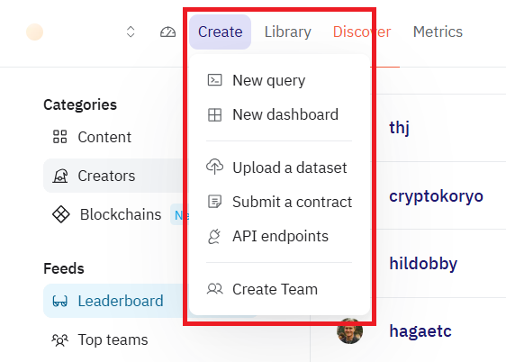

La voce *New query* propone la pagina per creare una nuova query. *New dashboard* propone la pagina per creare una nuova dashboard. Questa fornisce un modo per raccogliere gli output di più query e visualizzarli in un’unica pagina. Il risultato di una query viene riportato all’interno di un widget. Un widget può essere un’immagine, una tabella oppure un testo (2025q).

[figure not shown]

Nella dashboard di esempio i grafi e la tabella visibile sono gli output di alcune query. È possibile ottenere output aggiornati rieseguendo le query direttamente sulla pagina. Queste dashboard si possono esportare su GitHub e il loro url si può condividere su altre piattaforme.  
La voce *Upload a dataset* propone la pagina per caricare dati sulla piattaforma Dune. La voce *Submit a contract* propone la pagina per decodificare i contratti. Bisogna specificare la blockchain di interesse e l’indirizzo hash del contratto.  
La voce *API endpoints* propone la pagina per creare dei custom endpoints.

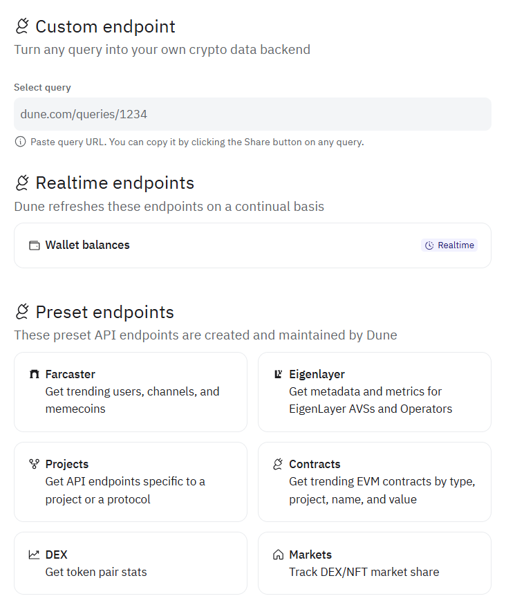

Gli endpoint sono creati utilizzando query. Queste query sono rieseguite ad intervalli regolari. È possibile ottenere l’output della query utilizzando un URL. Questo URL viene generato dalla piattaforma al momento della creazione di un endpoint. Un custom endpoint è poi salvato nel proprio account.  
Una volta creato un endpoint è possibile raffinarne i risultati utilizzando filtri, paginazione e ordinamenti. Per utilizzare la query è necessario creare una chiave API. Questa chiave è specifica per l’endpoint. È possibile ottenere i risultati dell’endpoint utilizzando Shell, Python, oppure TypeScript.  
Non è possibile creare endpoint con query che non appartengono all’account.